# Project 1: Wrangling, Exploration, Visualization

SDS322E

## Data Wrangling, Exploration, Visualization

### Nischal Shrestha

#### Introduction

*How important are critic’s reviews to the sales of a video game? I have always wondered this question, and now I have the ability to investigate it myself. In this project, I wanted analyze this question, specifically focusing on PS4 games as it was one of the largest platform for gaming for the last 4 years. I got both of my datasets from Kaggle.com. My first dataset is called the criticscores. It contains the name of the game, the console it was released on, the date of release, the metacritic score of a game, which is the aggregate score given to the game based on reviews from gaming journalists, and the game’s user score. My second dataset will be called the PS4sales which contains the name of the game, the year it was released, it’s genre, the publisher, and its sales in North America, Japan, Europe and the rest of the world. I picked these datasets because I wanted to analyze the effect of critical scores oo the sales of a video game; furthermore, I also wanted to analyze how important a negative score on other platforms is to the game’s sales on PS4 and if a particular genre or publisher was more reliant on critic scores than other genres or publisher.*

```r
# read your datasets in here, e.g., with read_csv()
library(tidyverse)
PS4sales <- read.csv("PS4_GamesSales.csv")
criticscores <- read.csv("result.csv")

PS4sales %>% glimpse()
```

```
## Rows: 1,034
## Columns: 9
## $ Game          <fct> Grand Theft Auto V, Call of Duty: Black Ops 3, Red Dead…
## $ Year          <fct> 2014, 2015, 2018, 2017, 2017, 2016, 2016, 2018, 2016, 2…
## $ Genre         <fct> Action, Shooter, Action-Adventure, Shooter, Sports, Spo…
## $ Publisher     <fct> Rockstar Games, Activision, Rockstar Games, Activision,…
## $ North.America <dbl> 6.06, 6.18, 5.26, 4.67, 1.27, 1.26, 4.49, 3.64, 3.11, 2…
## $ Europe        <dbl> 9.71, 6.05, 6.21, 6.21, 8.64, 7.95, 3.93, 3.39, 3.83, 3…
## $ Japan         <dbl> 0.60, 0.41, 0.21, 0.40, 0.15, 0.12, 0.21, 0.32, 0.19, 0…
## $ Rest.of.World <dbl> 3.02, 2.44, 2.26, 2.12, 1.73, 1.61, 1.70, 1.41, 1.36, 1…
## $ Global        <dbl> 19.39, 15.09, 13.94, 13.40, 11.80, 10.94, 10.33, 8.76, …
```

```r
criticscores %>% glimpse()
```

```
## Rows: 15,647
## Columns: 5
## $ metascore <int> 97, 97, 95, 94, 94, 93, 93, 92, 92, 91, 91, 91, 91, 90, 90,…
## $ name      <fct> Grand Theft Auto V, Grand Theft Auto V, The Last of Us, Bio…
## $ console   <fct> PS3, X360, PS3, PS3, PC, X360, WIIU, 3DS, WIIU, PC, PS3, 3D…
## $ userscore <fct> 8.3, 8.3, 9.2, 8.5, 8.6, 8.5, 8.9, 9.1, 8.7, 6.7, 8.7, 9, 7…
## $ date      <fct> "Sep 17, 2013", "Sep 17, 2013", "Jun 14, 2013", "Mar 26, 20…
```

#### Tidying: Reshaping

```r
# your tidying code (if applicable; can also wait until
# wrangling section)
criticscorestidy <- criticscores %>% select(!date & !userscore) %>%
    filter(console == "PS4" | console == "XONE") %>% pivot_wider(names_from = console,
    values_from = metascore) %>% na.omit()

criticscorestidy %>% glimpse()
```

```
## Rows: 581
## Columns: 3
## $ name <fct> FIFA 14, NBA 2K14, Grand Theft Auto V, Diablo III: Ultimate Evil…
## $ PS4  <int> 87, 85, 97, 90, 89, 87, 84, 87, 85, 85, 85, 83, 97, 91, 92, 88, …
## $ XONE <int> 88, 86, 97, 86, 85, 88, 87, 80, 86, 82, 82, 84, 98, 94, 93, 91, …
```

```r
# doing this isn't neccesary for the analysis but I need to
# show that I can pivot_longer
PSlonger <- PS4sales %>% pivot_longer(cols = -(1:4), names_to = "Region",
    values_to = "Sales")

PSlonger %>% glimpse()
```

```
## Rows: 5,170
## Columns: 6
## $ Game      <fct> Grand Theft Auto V, Grand Theft Auto V, Grand Theft Auto V,…
## $ Year      <fct> 2014, 2014, 2014, 2014, 2014, 2015, 2015, 2015, 2015, 2015,…
## $ Genre     <fct> Action, Action, Action, Action, Action, Shooter, Shooter, S…
## $ Publisher <fct> Rockstar Games, Rockstar Games, Rockstar Games, Rockstar Ga…
## $ Region    <chr> "North.America", "Europe", "Japan", "Rest.of.World", "Globa…
## $ Sales     <dbl> 6.06, 9.71, 0.60, 3.02, 19.39, 6.18, 6.05, 0.41, 2.44, 15.0…
```

```r
nrow(criticscores)
```

```
## [1] 15647
```

```r
nrow(criticscorestidy)
```

```
## [1] 581
```

*We modify the criticscores dataset to drop the date of release and the underscore, as they were irrelevant to the type of analysis we were going to focus on. We filter the data, so only the games that have a score for PS4 or Xbox one are left, as these consoles are from the same generation and will therefore have the most in common in terms of games. We then tidy the dataset so all the different scores for the different platforms a particular game was released on would be put on a single row, which also means that the number of unique ID is equal to the number of observations. Finally we remove the rows containing NA to remove all the exclusives as we only want to focus on title that were released on both platforms. We also observe that the number of rows in this dataset went down from 15647 to 581.*

#### Joining/Merging

```r
# your joining code
mergedGAmes <- inner_join(PS4sales, criticscorestidy, by = c(Game = "name"))
mergedGAmes %>% glimpse()
```

```
## Rows: 226
## Columns: 11
## $ Game          <fct> Grand Theft Auto V, Red Dead Redemption 2, Call of Duty…
## $ Year          <fct> 2014, 2018, 2017, 2017, 2016, 2016, 2015, 2015, 2014, 2…
## $ Genre         <fct> Action, Action-Adventure, Shooter, Sports, Sports, Shoo…
## $ Publisher     <fct> Rockstar Games, Rockstar Games, Activision, EA Sports, …
## $ North.America <dbl> 6.06, 5.26, 4.67, 1.27, 1.26, 3.11, 2.91, 1.15, 2.84, 2…
## $ Europe        <dbl> 9.71, 6.21, 6.21, 8.64, 7.95, 3.83, 3.97, 5.77, 3.34, 3…
## $ Japan         <dbl> 0.60, 0.21, 0.40, 0.15, 0.12, 0.19, 0.27, 0.07, 0.14, 0…
## $ Rest.of.World <dbl> 3.02, 2.26, 2.12, 1.73, 1.61, 1.36, 1.34, 1.23, 1.22, 1…
## $ Global        <dbl> 19.39, 13.94, 13.40, 11.80, 10.94, 8.48, 8.48, 8.22, 7.…
## $ PS4           <int> 97, 97, 79, 84, 85, 77, 87, 82, 83, 89, 82, 76, 92, 81,…
## $ XONE          <int> 97, 98, 80, 83, 84, 78, 88, 84, 81, 87, 82, 75, 91, 83,…
```

```r
# your joining code
nrow(criticscorestidy)  #observations for criticscorestidy; also the # of unique id
```

```
## [1] 581
```

```r
criticscorestidy %>% summarize(n_distinct(name))  #proof
```

```
## # A tibble: 1 x 1
##   `n_distinct(name)`
##                <int>
## 1                581
```

```r
nrow(PS4sales)  #observations for PS4sales
```

```
## [1] 1034
```

```r
PS4sales %>% summarize(n_distinct(Game))  # of unique id
```

```
##   n_distinct(Game)
## 1             1031
```

```r
nrow(mergedGAmes)  #observations for merged dataset; also the # of unique id
```

```
## [1] 226
```

```r
mergedGAmes %>% summarize(n_distinct(Game))  #proof
```

```
##   n_distinct(Game)
## 1              226
```

```r
anti_join(criticscorestidy, mergedGAmes, by = c(name = "Game")) %>%
    glimpse()  #games that are in criticscoretidy, but not in PS4sales
```

```
## Rows: 355
## Columns: 3
## $ name <fct> FIFA 14, Diablo III: Ultimate Evil Edition, Dragon Age: Inquisit…
## $ PS4  <int> 87, 90, 89, 87, 84, 87, 85, 83, 91, 92, 88, 89, 80, 85, 81, 87, …
## $ XONE <int> 88, 86, 85, 88, 87, 80, 86, 84, 94, 93, 91, 83, 88, 88, 88, 86, …
```

```r
anti_join(PS4sales, mergedGAmes, by = "Game") %>% glimpse()  #games that are in PS4sales but not in criticscoretidy
```

```
## Rows: 808
## Columns: 9
## $ Game          <fct> Call of Duty: Black Ops 3, Uncharted (PS4), Spider-Man …
## $ Year          <fct> 2015, 2016, 2018, 2015, 2014, 2014, 2018, 2017, 2015, 2…
## $ Genre         <fct> Shooter, Action, Action-Adventure, Shooter, Action-Adve…
## $ Publisher     <fct> Activision, Sony Interactive Entertainment, Sony Intera…
## $ North.America <dbl> 6.18, 4.49, 3.64, 3.31, 2.70, 1.89, 2.83, 2.20, 2.55, 1…
## $ Europe        <dbl> 6.05, 3.93, 3.39, 3.19, 2.86, 3.13, 2.17, 2.43, 2.11, 1…
## $ Japan         <dbl> 0.41, 0.21, 0.32, 0.23, 0.11, 0.35, 0.13, 0.28, 0.10, 0…
## $ Rest.of.World <dbl> 2.44, 1.70, 1.41, 1.30, 1.10, 0.96, 1.02, 0.92, 0.94, 0…
## $ Global        <dbl> 15.09, 10.33, 8.76, 8.03, 6.77, 6.33, 6.15, 5.82, 5.70,…
```

#### Wrangling

```r
# your wrangling code

library(kableExtra)
mG2 <- mergedGAmes %>% mutate(NApercent = North.America/Global) %>%
    mutate(Eupercent = Europe/Global) %>% mutate(JPpercent = Japan/Global) %>%
    mutate(otherpercent = Rest.of.World/Global) %>% select((!North.America) &
    (!Europe) & (!Japan) & (!Rest.of.World))
# these mutations gives us the percentage of sales made in
# NA, Europe, Japan, and the rest of the world for each game,
# and drops the total number of sales made in these regions
# as they are irrelevant for the rest of our analysis


# your wrangling code
mG2 %>% mutate(length = str_length(Game)) %>% filter(length ==
    max(length))  #this tells us that the most wordy game is Teenage Mutant Ninja Turtles: Mutants in Manhattan
```

```
##                                                 Game Year  Genre  Publisher
## 1 Teenage Mutant Ninja Turtles: Mutants in Manhattan 2016 Action Activision
##   Global PS4 XONE NApercent Eupercent JPpercent otherpercent length
## 1   0.12  44   55 0.5833333      0.25         0    0.1666667     50
```

```r
# your wrangling code
mG2 %>% filter(Eupercent > 0.5) %>% group_by(Genre, Publisher) %>%
    summarize(avg = mean(PS4), std = sd(PS4), median = median(PS4),
        max = max(PS4)) %>% na.omit() %>% kbl()  #this gives us the mean, standard deviation, and median metacritic score for the PS4 versions of games that were primarily popular in Europe. It is also grouped by genre and publisher, if a publisher has only made 1 game of a particular genre they are not included.
```

| Genre | Publisher | avg | std | median | max |
| --- | --- | --- | --- | --- | --- |
| Action | Bethesda Softworks | 85.00000 | 4.242641 | 85.0 | 88 |
| Action | Ubisoft | 79.66667 | 3.214550 | 81.0 | 82 |
| Action-Adventure | Square Enix | 66.00000 | 9.899495 | 66.0 | 73 |
| Racing | Codemasters | 78.33333 | 11.547005 | 85.0 | 85 |
| Racing | Ubisoft | 62.50000 | 2.121320 | 62.5 | 64 |
| Shooter | Bethesda Softworks | 77.50000 | 2.121320 | 77.5 | 79 |
| Sports | EA Sports | 82.66667 | 1.154700 | 82.0 | 84 |
| Sports | Konami Digital Entertainment | 84.66667 | 2.516611 | 85.0 | 87 |

```r
mG2 %>% filter(NApercent > 0.5) %>% group_by(Genre, Publisher) %>%
    summarize(avg = mean(PS4), std = sd(PS4), median = median(PS4),
        max = max(PS4)) %>% na.omit() %>% kbl()  #this gives us the mean, standard deviation, and median metacritic score for the PS4 versions of games that were primarily popular in America. It is also grouped by genre and publisher, if a publisher has only made 1 game of a particular genre they are not included.
```

| Genre | Publisher | avg | std | median | max |
| --- | --- | --- | --- | --- | --- |
| Fighting | Warner Bros. Interactive Entertainment | 85.00 | 2.828427 | 85.0 | 87 |
| Shooter | 2K Games | 75.00 | 9.899495 | 75.0 | 82 |
| Sports | 2K Sports | 84.60 | 3.209361 | 85.0 | 88 |
| Sports | EA Sports | 72.25 | 12.211210 | 76.5 | 83 |

```r
mG2 %>% filter(JPpercent > 0.5) %>% group_by(Genre, Publisher) %>%
    summarize(avg = mean(PS4), std = sd(PS4), median = median(PS4),
        max = max(PS4)) %>% kbl()  #this gives us the mean, standard deviation, and median metacritic score for the PS4 versions of games that were primarily popular in Japan. It is also grouped by genre and publisher.
```

| Genre | Publisher | avg | std | median | max |
| --- | --- | --- | --- | --- | --- |
| Role-Playing | Active Gaming Media | 80 | NA | 80 | 80 |
| Role-Playing | Ubisoft | 82 | NA | 82 | 82 |

```r
mG2 %>% filter(otherpercent > 0.5) %>% group_by(Genre, Publisher) %>%
    summarize(avg = mean(PS4), std = sd(PS4), median = median(PS4),
        max = max(PS4)) %>% kbl()  #this gives us the mean, standard deviation, and median metacritic score for the PS4 versions of games that were primarily popular in the rest of the world. It is also grouped by genre and publisher.
```

| Genre | Publisher | avg | std | median | max |
| --- | --- | --- | --- | --- | --- |

```r
avescoreacrossplatform <- function(x, y) {
    # this function will give us the average score of the games
    # across the two platforms
    0.5 * (mean(x) + mean(y))
}

mG2 %>% group_by(Publisher) %>% summarize(Averagescore = avescoreacrossplatform(PS4,
    XONE)) %>% na.omit()  #This will give us the average score of the games released by a Publisher between the Xbox one and PS4 metacritic score
```

```
## # A tibble: 56 x 2
##    Publisher             Averagescore
##    <fct>                        <dbl>
##  1 ""                            69.2
##  2 "2K Games"                    74.8
##  3 "2K Sports"                   78.8
##  4 "505 Games"                   71.6
##  5 "Active Gaming Media"         78
##  6 "Activision"                  72.4
##  7 "Badland Studio"              79.5
##  8 "Bandai Namco Games"          71.5
##  9 "Bethesda Softworks"          81.6
## 10 "Bigben Interactive"          67.5
## # … with 46 more rows
```

```r
# categorical data
mG2 %>% group_by(Genre) %>% summarize(n = n()) %>% arrange(desc(n))
```

```
## # A tibble: 15 x 2
##    Genre                n
##    <fct>            <int>
##  1 Action              46
##  2 Sports              38
##  3 Shooter             27
##  4 Role-Playing        24
##  5 Adventure           17
##  6 Racing              14
##  7 Platform            13
##  8 Action-Adventure    12
##  9 Misc                10
## 10 Fighting             7
## 11 Simulation           7
## 12 Music                4
## 13 Puzzle               3
## 14 Strategy             3
## 15 MMO                  1
```

```r
mG2 %>% group_by(Publisher) %>% summarize(n = n()) %>% arrange(desc(n))
```

```
## # A tibble: 56 x 2
##    Publisher                                    n
##    <fct>                                    <int>
##  1 ""                                          27
##  2 "Ubisoft"                                   19
##  3 "EA Sports"                                 17
##  4 "Activision"                                14
##  5 "Electronic Arts"                           10
##  6 "Warner Bros. Interactive Entertainment"    10
##  7 "Namco Bandai Games"                         9
##  8 "Bethesda Softworks"                         8
##  9 "2K Sports"                                  7
## 10 "505 Games"                                  7
## # … with 46 more rows
```

*It’s interesting that Konami and Square Enix have genres that are primarily popular in Europe even though they are a Japanese company and most of their games have a very distinct Japanese style to them. Similarly, Ubisoft which is a French company also has a genre that is primarily popular in Japan. It shows how the medium of video games can cause different cultures to appreciate each other which is very cool. It’s also interesting that North America, Europe and Japan make up the vast majority of global game sales as there were no games that were primarily popular in the rest of the world in terms of sales. It’s particularly interesting considering how big gaming is in China and Korea. This is probably because these countries are more focused on PC gaming rather than consoles like the PS4.*

#### Visualizing

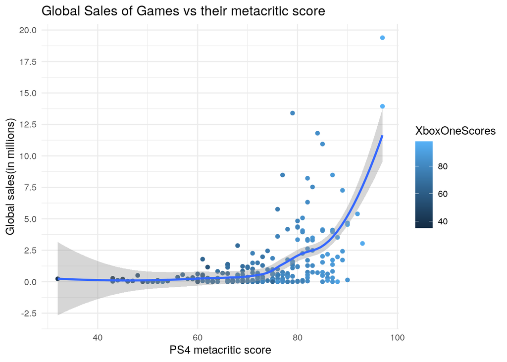

```r
# your plot 1
mG2 <- mG2 %>% rename(XboxOneScores = "XONE")
ggplot(data = mG2, aes(x = PS4, y = Global, color = XboxOneScores)) +
    geom_point() + geom_smooth() + xlab("PS4 metacritic score") +
    ylab("Global sales(in millions)") + ggtitle("Global Sales of Games vs their metacritic score") +
    theme_minimal() + scale_y_continuous(n.breaks = 10)
```

*From this plot, we can see that the relationship between the PS4 metacritic score of a game and the global sales of that game is not linear. In fact, there is little to no relationship until the game hits a score of around 70, which makes sense to me as most people seem to consider 70 to be decent and anyting less to be bad, and not worth their time even though 50 should mean that it is average. Thus explaining the low amount of sales for games below the score of 70 except for some outliers. We can also see from the colors that the trend on Xbox one scores is the same, as in we can use the Xbox one metacritic score to determine the global sales for PS4 which is as expected as most multiplatform games are unlikely to have a staggering difference in critical reception*

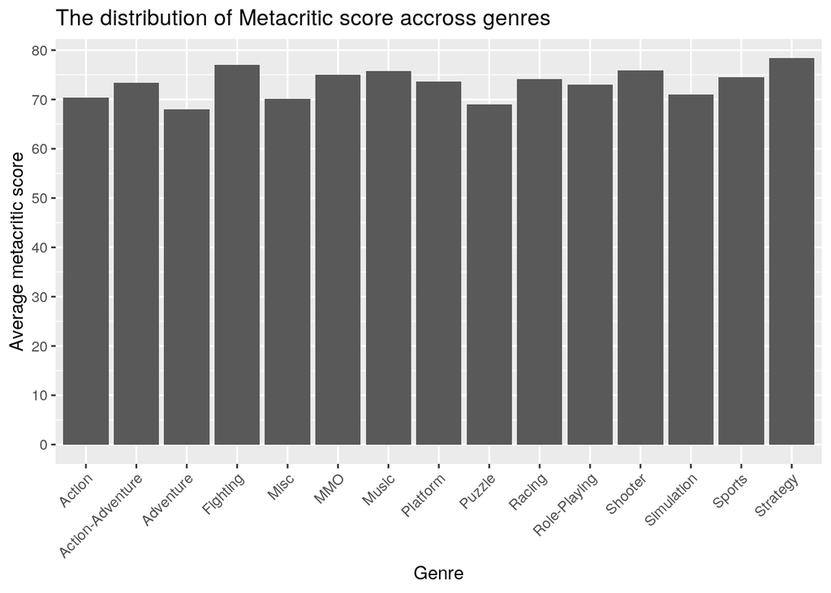

```r
# your plot 2
ggplot(data = mG2, aes(x = Genre)) + geom_bar(aes(y = PS4), stat = "summary",
    fun = mean) + xlab("Genre") + ylab("Average metacritic score") +
    theme(axis.text.x = element_text(angle = 45, hjust = 1),
        legend.position = "none") + ggtitle("The distribution of Metacritic score accross genres") +
    scale_y_continuous(n.breaks = 10) + scale_fill_brewer()
```

*We can see in this plot that the average metacritic score for most genres seems to be relatively the same. Fighting games, strategy, and Music seems to have the highest average scores, but not by much. Most Genres seem to have an average metacritic score greater than 70. This suggest that even though there is an expectation that a game should have at least a 70 before being successful most genres seem to be able produce games that meet that standard for reviewers.*

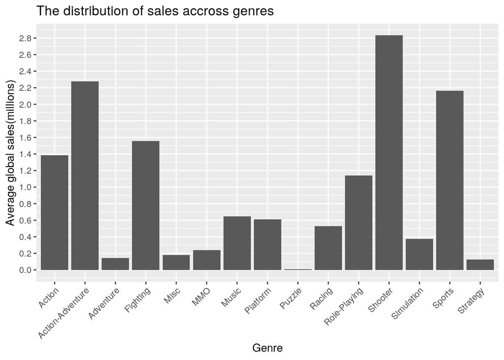

```r
# your plot 3
ggplot(data = mG2, aes(x = Genre)) + geom_bar(aes(y = Global),
    stat = "summary", fun = mean) + xlab("Genre") + ylab("Average global sales(millions)") +
    theme(axis.text.x = element_text(angle = 45, hjust = 1),
        legend.position = "none") + ggtitle("The distribution of sales accross genres") +
    scale_y_continuous(n.breaks = 20)
```